# Assignment #3

Emma Holmes

February 23, 2023

### Download and Read Data

```r
wavac <- read_csv("WA_VACC_SCHDIST_2017.csv")
```

### Washington Data Summary

The Washington school district data file has 294 rows (school districts) and 11 columns. 26 school districts reported “No Data” for enrollment and vaccination data. Statewide in 2017, there were 80523 kindergarteners, and 68995 of these kindergarteners were up to date on vaccinations, for an up to date percent of 85.7.

### Question 1

There are 8 files associated with the Washington School Districts shapefile, including the .shp file.

```r
# Read in WA school district shapefile
wa.sd.sp <- st_read("wa_schdist_shapefile/WA_SCHDIST.shp")
wa.sd.sp  # provides summary info about the object!
```

```
## Simple feature collection with 294 features and 4 fields
## Geometry type: MULTIPOLYGON
## Dimension:     XY
## Bounding box:  xmin: 368970.8 ymin: 5044113 xmax: 971101.2 ymax: 5444545
## Projected CRS: NAD83 / UTM zone 10N
## First 10 features:
##      GEOID                              NAME LOGRADE HIGRADE
## 1  5307620             Royal School District      KG      12
## 2  5300780 Burlington-Edison School District      PK      12
## 3  5301680            Conway School District      KG      12
## 4  5308820            Tenino School District      KG      12
## 5  5304110         La Conner School District      KG      12
## 6  5305400      Mount Vernon School District      KG      12
## 7  5301410       Clover Park School District      PK      12
## 8  5302370        Eatonville School District      PK      12
## 9  5306690         Peninsula School District      PK      12
## 10 5308610            Sumner School District      PK      12
##                          geometry
## 1  MULTIPOLYGON (((756882.6 52...
## 2  MULTIPOLYGON (((538786.5 53...
## 3  MULTIPOLYGON (((546195.5 53...
## 4  MULTIPOLYGON (((516676.7 51...
## 5  MULTIPOLYGON (((537427.8 53...
## 6  MULTIPOLYGON (((554039.6 53...
## 7  MULTIPOLYGON (((540689.8 52...
## 8  MULTIPOLYGON (((568055.3 51...
## 9  MULTIPOLYGON (((521582.4 52...
## 10 MULTIPOLYGON (((556773.6 52...
```

```r
# Check if valid geometry
sum(st_is_valid(wa.sd.sp)) ## Equal to number of features?
```

```
## [1] 292
```

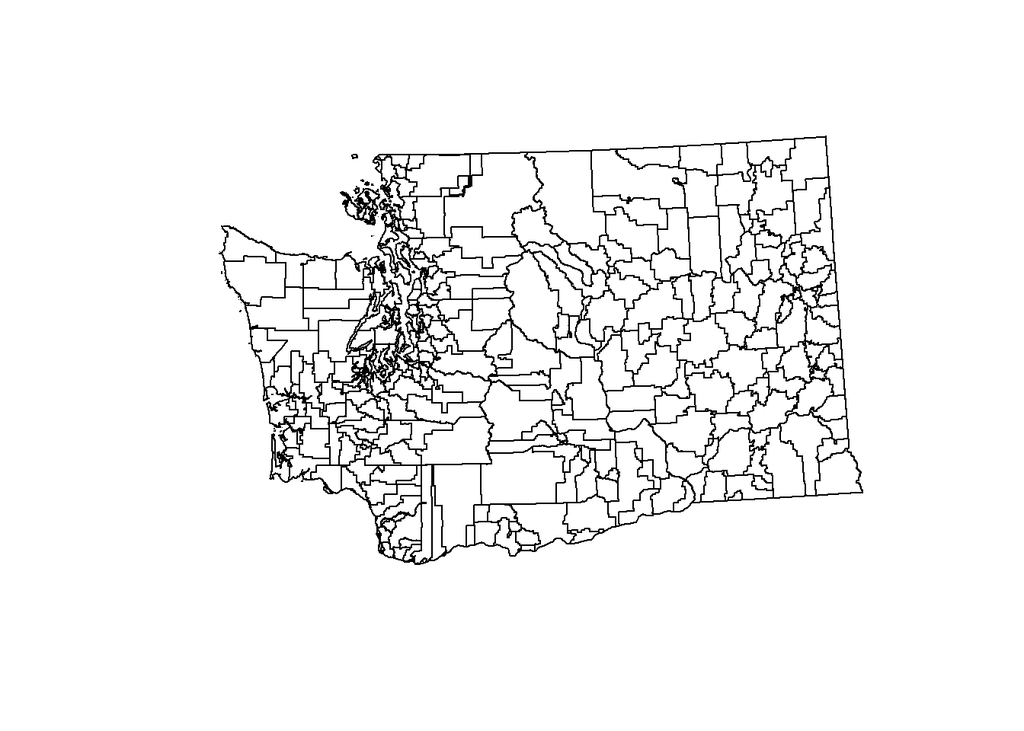

```r
# Fix geometry (easiest attempt)
wa.sd.sp <- st_make_valid(wa.sd.sp)

# Plot the geometry to display the polygon
plot(st_geometry(wa.sd.sp))
```

### Question 2

There are 294 observations/features and 4 columns/variables in the Washington School Districts shapefile. In the Washington School Districts shapefile bounding box, the northernmost coordinate is (X, 5444545).

```r
## Extract the attributes (data.frame) from an sf object
wa.sd.sp.att.data.only <- st_drop_geometry(wa.sd.sp)

## Get info
str(wa.sd.sp.att.data.only)
```

```
## 'data.frame':    294 obs. of  4 variables:
##  $ GEOID  : chr  "5307620" "5300780" "5301680" "5308820" ...
##  $ NAME   : chr  "Royal School District" "Burlington-Edison School District" "Conway School District" "Tenino School District" ...
##  $ LOGRADE: chr  "KG" "PK" "KG" "KG" ...
##  $ HIGRADE: chr  "12" "12" "12" "12" ...
```

```r
## Extract a single column of (attribute) data
sd.names <- wa.sd.sp$NAME
sd.names[1:6]
```

```
## [1] "Royal School District"             "Burlington-Edison School District"
## [3] "Conway School District"            "Tenino School District"
## [5] "La Conner School District"         "Mount Vernon School District"
```

```r
## Add a new column/variable to the sf object
wa.sd.sp$NEWCOLUMN <- 1:294

## Remove a column/variable from the sf object
wa.sd.sp$NEWCOLUMN <- NULL

## Query a column and subset
## Which school districts have PK (pre-kindergarten)?
pk.sds <- which(wa.sd.sp$LOGRADE == "PK")
length(pk.sds) # How many?
```

```
## [1] 185
```

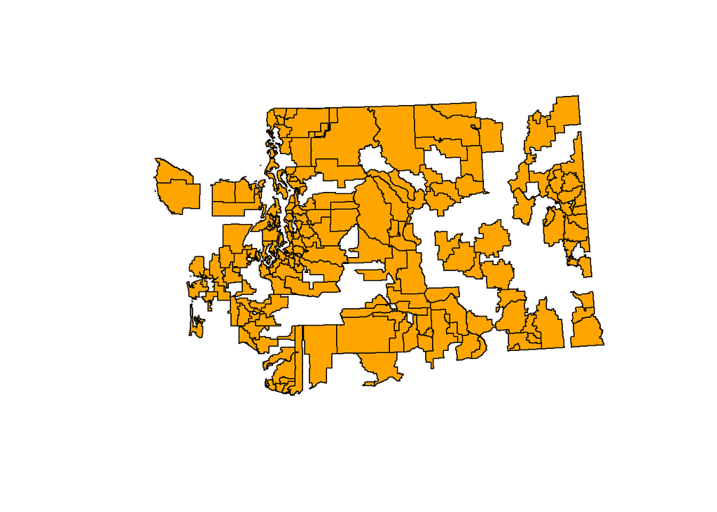

```r
## Create a new spatial data layer containing ONLY the
## school districts that have PK (subset the data)
wa.sd.sp.pk <- wa.sd.sp[pk.sds,]

## Plot the subset
plot(st_geometry(wa.sd.sp.pk), col = "orange")
```

### Question 3

185 Washington School Districts have pre-kindergarten.

### Table Join and Map

```r
# Test if wa.sd.sp and wavac are a perfect match for a join
all(wa.sd.sp$GEOID %in% wavac$GEOID)
```

```
## [1] TRUE
```

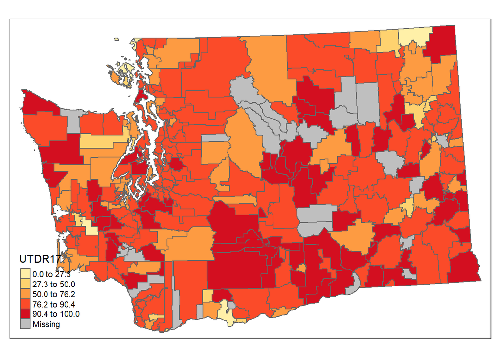

```r
# Join vaccination data to spatial data
wa.sd.sp <- merge(wa.sd.sp,      # Spatial Data layer
                  wavac,         # Table Data layer
                  by = "GEOID")  # Key field (this is both)

## Calculate column with Percent Up to Date
wa.sd.sp$UTDR17 <- 100 * wa.sd.sp$UTD17 / wa.sd.sp$ENR17

## Create map
tm_shape(wa.sd.sp) +
  tm_polygons("UTDR17",
              style = "jenks",
              palette = "YlOrRd")
```

### Question 4

In wavac, the data type of GEOID is numeric. And in wa.sd.sp the data type of GEOID is character. This information is found in the environment, before the data in the column it shows the data type as “num” in wavac and “chr” in wa.sd.sp.

### Question 5

The functions `all(1:10 %in% 1:10)` and `all(1:5 %in% 1:10)` both equal `TRUE` because the data that is found in 1:10 is also found in 1:10 and the data found in 1:5 is also in 1:10. However, `all(1:10 %in% 1:5)` equal `FALSE` because not all of the data in 1:10 is going to be in 1:5 as 1:10 is too big to fit into 1:5. There is 1,2,3,4,5 (1:5) in 1,2,3,4,5,6,7,8,9,10 (1:10) but not 1,2,3,4,5,6,7,8,9,10 (1:10) in 1,2,3,4,5 (1:5).

### Question 6

There are definitely chunks of districts that have the highest percent of vaccinations and these are closer to the southern border of Washington state. And the upper-right corner has a cluster of lighter oranges and yellows, signifiying a cluster of districts with lower vaccination rates, although there is one district in the middle with 90.4 to 100% vaccinated. I was surprised that Seattle was not darker as a large city, and central Seattle does have dark red districts, but to the immediate left of Seattle the districts have low rates of vaccination. It’d be interesting to view this map with large cities shown as points on it, to compare the rural and urban vaccinations (I don’t know enough about Washington geography to know this off the top of my head, other than Seattle).